# Classification Accuracy

Dr. Josh Jacobson

16 January 2026

*These lecture notes were originally developed by Dr. Kris Pruitt.*

The purpose of this lesson is to compute and explain the primary metrics for assessing the prediction accuracy of a classification model. Specifically, we explore classification error rate for training and testing sets.

# Training versus Testing Data

Just as with regression models, it is critical that we split our sample data into training and testing sets. The training set is used to develop the model, while the testing set is used to evaluate its prediction accuracy. We once again divide our data into 75% training and 25% testing for this lesson. Import and wrangle the built-in data set `lakers` below. The data includes play-by-play results for all basketball games played by the Los Angeles Lakers in the 2008-2009 seasons.

```r
# import lakers data
data("lakers")


# add distance of shot, then format and clean the data
# center of the hoop is located at (25, 5.25)
# include only shots within 30 feet
lakers2 <- lakers %>%
  filter(etype == "shot") %>%
  mutate(
    distance = sqrt((x - 25)^2 + (y - 5.25)^2),
    result = as.factor(result)
  ) %>%
  select(distance, result) %>%
  filter(distance < 30) %>%
  na.omit()

# summarize data
summary(lakers2)
```

```
##     distance        result
##  Min.   : 0.25   made  :6003
##  1st Qu.: 0.75   missed:7001
##  Median :13.46
##  Mean   :12.62
##  3rd Qu.:22.00
##  Max.   :29.85
```

Our goal is to classify (predict) a shot as either made or missed based on the distance of the shooter from the basket. Prior to any analysis, we randomly split the sample such that 75% of shots are used for training and the remaining 25% are used for testing.

```r
# set randomization seed
set.seed(45)

# randomly select training rows
rows <- sample(x = nrow(lakers2), size = floor(0.75 * nrow(lakers2)), replace = FALSE)

# extract training and testing sets
training <- lakers2[rows, ]
testing <- lakers2[-rows, ]
```

Ideally, the two sets are each representative of the population of all shots. At the very least, the mean response should be similar. In this case, the response is a binary outcome (made or missed). So, the *mean* response is equivalent to the proportion of values defined as 1 (versus 0). Let’s define a made shot as 1 and compute the proportions in the training and testing sets below.

```r
# compute mean response
mean(training$result == "made")
```

```
## [1] 0.4588332
```

```r
mean(testing$result == "made")
```

```
## [1] 0.4700092
```

Given our large sample size, the proportion of made shots in the training and testing sets are very close. With the sample appropriately split, we are ready to construct and evaluate a model.

# Classification Models

Let’s begin by exploring the distribution of shot distance based on result. A comparative box plot is a good choice for this task.

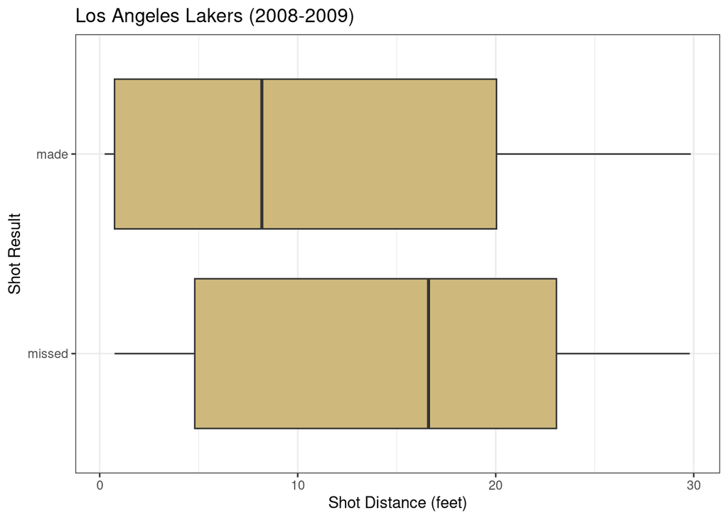

```r
# construct box plot
ggplot(data = training, aes(x = distance, y = reorder(result, -distance))) +
  geom_boxplot(fill = "#CFB87C") +
  labs(
    title = "Los Angeles Lakers (2008-2009)",
    x = "Shot Distance (feet)",
    y = "Shot Result"
  ) +
  theme_bw()
```

There does appear to be some evidence of a difference in the distributions of distance, but it is unclear how significant. Although box plots are nice for exploration, they are a poor choice for depicting predictive models. Instead, we depict the association between shot distance and result using a scatter plot. Because our response variable is binary (make=1, miss=0), the $y$-axis in a scatter plot represents the *probability* of making a shot.

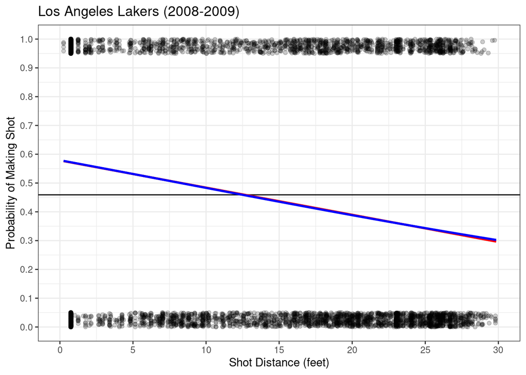

```r
# create scatter plot
ggplot(data = training, aes(x = distance, y = ifelse(result == "made", 1, 0))) +
  geom_jitter(width = 0, height = 0.05, alpha = 0.2) +
  geom_hline(yintercept = 0.459, color = "black") +
  geom_smooth(formula = y ~ x, method = "lm", se = FALSE, color = "red") +
  geom_smooth(
    formula = y ~ x, method = "glm", se = FALSE, color = "blue",
    method.args = list(family = "binomial")
  ) +
  labs(
    title = "Los Angeles Lakers (2008-2009)",
    x = "Shot Distance (feet)",
    y = "Probability of Making Shot"
  ) +
  scale_x_continuous(limits = c(0, 30), breaks = seq(0, 30, 5)) +
  scale_y_continuous(limits = c(0, 1), breaks = seq(0, 1, 0.1)) +
  theme_bw()
```

Notice we add some jitter to the points in the plot to better display the dispersion. This is purely a *visual* adjustment. All of the response values are exactly equal to 0 or 1. The graphic also depicts three different classification models we might choose to employ. The horizontal black line represents the proportion of made shots in the training set. In other words, we could simply guess the average shooting percentage for all shots, regardless of distance. This suggests the following model:

$$P(y=1)=0.459$$

The second model (red line) assumes a linear relationship between the two variables and determines the best fit. Generally speaking, linear models do not perform well for binary response variables (why?). However, we consider it here for purposes of comparison.

$$P(y=1)=0.579-0.009x$$

Given the negative slope, the linear model suggests shooters are less likely to make long-distance shots. Finally, the third model (blue curve) assumes a logistic (sigmoid) relationship between distance and result. The logistic function is a much more common choice for binary outcomes and generally performs better than linear functions. However, in this case, there appears to be little difference over the range of distances under consideration.

$$P(y=1)=\frac{1}{1+e^{-(0.320-0.039x)}}$$

Based purely on a visual assessment, which of these three models do we expect to perform the best? Clearly, the average model is a poor choice because it ignores distance. But it is difficult to tell whether the linear or logistic model is more accurate. Let’s compute an objective metric of accuracy in the next section.

# Classification Error Rate

Now we want to assess the accuracy of each model using the testing data. For a binary response variable, a popular metric is the classification error rate (CER). For a testing set with $n$ observations, let $y_i$ be the true response value for the $i$th observation and $\hat{y}_i$ be the predicted value. Then the CER is calculated as follows.

$$\text{CER}=\frac{\sum_i I(y_i\neq\hat{y}_i)}{n}$$

The indicator function $I(y_i\neq\hat{y}_i)$ return a 1 (TRUE) when the classification does not match reality and a 0 (FALSE) otherwise. We then average all of these binary values by adding them up and dividing by the number of observation. However, there is an additional step we must first take before we can compute CER.

The models presented in the previous section all result in the probability $P(y=1)$. This is *not* the same thing as $\hat{y}$, which must be equal to either 1 or 0. In order to convert the response from a probability to a binary outcome, we need a **classification threshold**. For now we will make the obvious choice of 0.5 for our threshold. In other words, when $P(y=1)>0.5$ we assign $\hat{y}=1$. Later in the course we will adjust this threshold. Let’s compute CER for our basketball models.

```r
# predict weight using each model
lakers_predict <- testing %>%
  mutate(
    prob_avg = 0.459,
    result_avg = "missed",
    prob_lin = 0.579 - 0.009 * distance,
    result_lin = ifelse(prob_lin > 0.5, "made", "missed"),
    prob_log = 1 / (1 + exp(-0.320 + 0.039 * distance)),
    result_log = ifelse(prob_log > 0.5, "made", "missed")
  )

# compute CER for all models
lakers_predict %>%
  summarize(
    CER_avg = mean(result_avg != result),
    CER_lin = mean(result_lin != result),
    CER_log = mean(result_log != result)
  )
```

| CER_avg | CER_lin | CER_log |
| --- | --- | --- |
| 0.4700092 | 0.3924946 | 0.3903414 |

Which model predicts shot result more accurately? Does that align with what we observed in the scatter plot? Why does so much error still remain in our model?